# Experiment 2: Loan Amount Prediction using Linear Regression

# Subject: UCS2612 – Machine Learning Algorithms Laboratory

**Name : Harishkanna R**  
**Sec : CSE-A**  
**Reg : 3122235001302**

# Linear Regression for Loan Amount Prediction

## 1) Aim

#### To build and evaluate a Linear Regression model for predicting the loan amount sanctioned to users using historical loan data, and to analyze model performance through evaluation metrics and visualizations.

## 2) Libraries Used

```python
import numpy as np
import pandas as pd
import matplotlib.pyplot as plt
import seaborn as sns

from sklearn.model_selection import train_test_split, KFold, cross_val_score
from sklearn.preprocessing import StandardScaler
from sklearn.linear_model import LinearRegression
from sklearn.metrics import mean_absolute_error, mean_squared_error, r2_score
```

## 3)Objective

#### The primary objective of this project is to develop a data-driven model that predicts the eligible loan amount for an applicant using Linear Regression, based on key financial and demographic attributes.

## 4) Mathematical Description

### Linear Regression Equation

**General form:**

y = b₀ + b₁x₁ + b₂x₂ + … + bₙxₙ

Where:

- y → predicted output (Loan Amount)
- b₀ → intercept (bias)
- b₁, b₂, …, bₙ → coefficients
- x₁, x₂, …, xₙ → input features

### Simple Linear Regression (y = mx + b)

y = mx + b

Where:

- y → predicted value
- m → slope (rate of change)
- x → input variable
- b → intercept

## 5) Code with plot

## Data Loading

```python
df = pd.read_csv("loan_train.csv")
df.head()
```

|  | Customer ID | Name | Gender | Age | Income (USD) | Income Stability | Profession | Type of Employment | Location | Loan Amount Request (USD) | ... | Credit Score | No. of Defaults | Has Active Credit Card | Property ID | Property Age | Property Type | Property Location | Co-Applicant | Property Price | Loan Sanction Amount (USD) |
| --- | --- | --- | --- | --- | --- | --- | --- | --- | --- | --- | --- | --- | --- | --- | --- | --- | --- | --- | --- | --- | --- |
| 0 | C-36995 | Frederica Shealy | F | 56 | 1933.05 | Low | Working | Sales staff | Semi-Urban | 72809.58 | ... | 809.44 | 0 | NaN | 746 | 1933.05 | 4 | Rural | 1 | 119933.46 | 54607.18 |
| 1 | C-33999 | America Calderone | M | 32 | 4952.91 | Low | Working | NaN | Semi-Urban | 46837.47 | ... | 780.40 | 0 | Unpossessed | 608 | 4952.91 | 2 | Rural | 1 | 54791.00 | 37469.98 |
| 2 | C-3770 | Rosetta Verne | F | 65 | 988.19 | High | Pensioner | NaN | Semi-Urban | 45593.04 | ... | 833.15 | 0 | Unpossessed | 546 | 988.19 | 2 | Urban | 0 | 72440.58 | 36474.43 |
| 3 | C-26480 | Zoe Chitty | F | 65 | NaN | High | Pensioner | NaN | Rural | 80057.92 | ... | 832.70 | 1 | Unpossessed | 890 | NaN | 2 | Semi-Urban | 1 | 121441.51 | 56040.54 |
| 4 | C-23459 | Afton Venema | F | 31 | 2614.77 | Low | Working | High skill tech staff | Semi-Urban | 113858.89 | ... | 745.55 | 1 | Active | 715 | 2614.77 | 4 | Semi-Urban | 1 | 208567.91 | 74008.28 |

5 rows × 24 columns

```python
df.shape
```

```
(30000, 24)
```

# Data Preprocessing

```python
df.isnull().sum()
```

```
Customer ID                       0
Name                              0
Gender                           53
Age                               0
Income (USD)                   4576
Income Stability               1683
Profession                        0
Type of Employment             7270
Location                          0
Loan Amount Request (USD)         0
Current Loan Expenses (USD)     172
Expense Type 1                    0
Expense Type 2                    0
Dependents                     2493
Credit Score                   1703
No. of Defaults                   0
Has Active Credit Card         1566
Property ID                       0
Property Age                   4850
Property Type                     0
Property Location               356
Co-Applicant                      0
Property Price                    0
Loan Sanction Amount (USD)      340
dtype: int64
```

```python
df=df.drop(columns=['Customer ID', 'Name', 'Gender', 'Age', 'Income (USD)',
       'Income Stability', 'Profession', 'Type of Employment', 'Location',
       'Expense Type 1', 'Expense Type 2', 'Dependents',
       'No. of Defaults', 'Has Active Credit Card', 'Property ID',
       'Property Age', 'Property Type', 'Property Location', 'Co-Applicant'],axis=1)
```

```python
df.fillna(df.mean(numeric_only=True),inplace=True)
for col in df.select_dtypes(include="object"):
    df[col].fillna(df[col].mode()[0])
```

```python
# cat_cols = df.select_dtypes(include='object').columns
# df[cat_cols].nunique().sort_values(ascending=False)
```

```python
df.columns
```

```
Index(['Loan Amount Request (USD)', 'Current Loan Expenses (USD)',
       'Credit Score', 'Property Price', 'Loan Sanction Amount (USD)'],
      dtype='object')
```

```python
scaler = StandardScaler()

X = df[["Current Loan Expenses (USD)","Loan Amount Request (USD)","Credit Score","Property Price"]]
y = df["Loan Sanction Amount (USD)"]

X_scaled = scaler.fit_transform(X)
```

## Exploratory Data Analysis

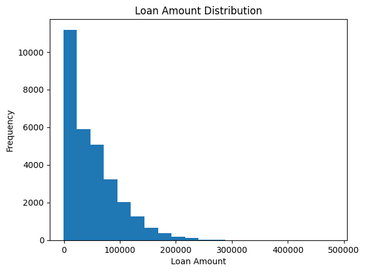

```python
plt.hist(y,bins=20)
plt.title("Loan Amount Distribution")
plt.xlabel("Loan Amount")
plt.ylabel("Frequency")
plt.show()
```

**Scatter Plot**

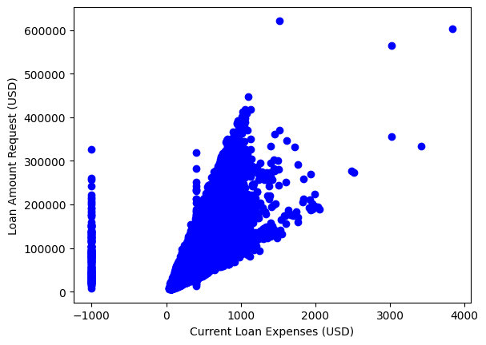

```python
plt.scatter(df['Current Loan Expenses (USD)'],df['Loan Amount Request (USD)'],color="blue")
plt.xlabel("Current Loan Expenses (USD)")
plt.ylabel("Loan Amount Request (USD)")
plt.show()
```

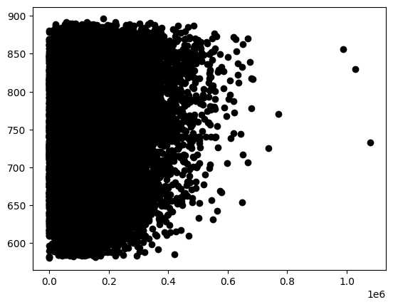

```python
plt.scatter(df['Property Price'],df['Credit Score'],color="black")
plt.show()
```

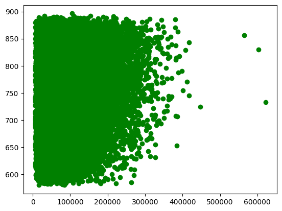

```python
plt.scatter(df['Loan Amount Request (USD)'],df['Credit Score'],color="green")
plt.show()
```

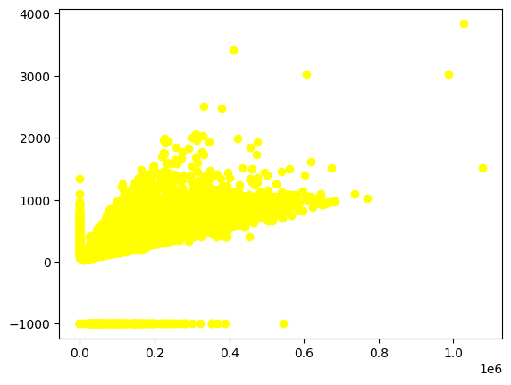

```python
plt.scatter(df['Property Price'],df['Current Loan Expenses (USD)'],color="yellow")
plt.show()
```

**Box Plot**

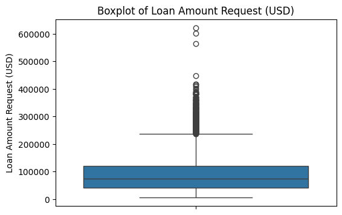

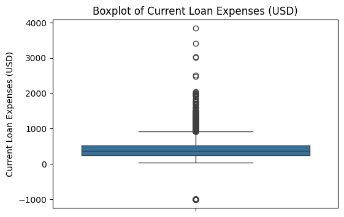

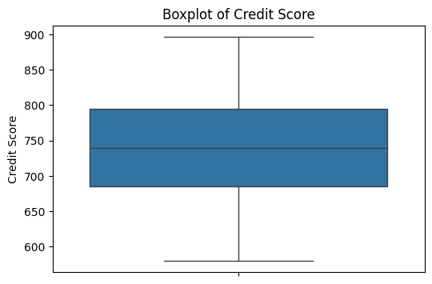

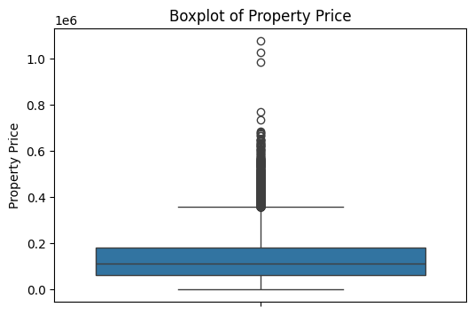

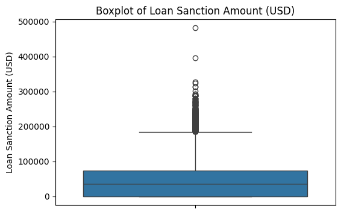

```python
col=df.columns
for c in col:
    plt.figure(figsize=(6,4))
    sns.boxplot(y=df[c])
    plt.title(f"Boxplot of {c}")
    plt.show()
```